# Analiza danych demograficznych z wyborów prezydenckich w USA w 2020 roku

## 1. Przedstawienie tematu

### Cel:

- Celem analizy jest zbadanie związków między wynikami wyborów prezydenckich w USA w 2020 roku a czynnikami demograficznymi, zawodowymi oraz wskaźnikami ekonomicznymi, takimi jak dochody, stopień edukacji, etniczność, zatrudnienie. Warto dodać, że te wybory prezydenckie mniały rekordową frekwencję - 66.7% osób uprawnionych do głosowania wzięło udział. Wpłynęły na nią silne emocje i polaryzacja wokół obu kandydatów - Donalda Trumpa oraz Joe Bidena.

### Źródło danych:

- Dane demograficzne: https://www.kaggle.com/datasets/essarabi/ultimate-us-election-dataset/data
- Dane o wynikach wyborów: https://dataverse.harvard.edu/dataset.xhtml?persistentId=doi:10.7910/DVN/42MVDX
- Dane przestrzenne do mapy USA: https://www.naturalearthdata.com/downloads/110m-cultural-vectors/110m-admin-1-states-provinces/

### Autor :

- Kamil Burza

## 2. Biblioteki

```python
import pandas as pd
import geopandas as gpd
import matplotlib.pyplot as plt
import matplotlib.patches as mpatches
from mpl_toolkits.axes_grid1.inset_locator import inset_axes
import numpy as np
import seaborn as sns
from sklearn.cluster import KMeans
from sklearn.decomposition import PCA
from sklearn.preprocessing import StandardScaler
import plotly.express as px
import plotly.io as pio
import os
os.environ["OMP_NUM_THREADS"] = "1"
```

```python
# Poprawne generowanie html-a
pio.renderers.default = "notebook_connected"
```

## 3. Wczytanie danych

```python
# Wczytanie danych o wyborach 2020
dane = pd.read_csv("US_Election_dataset_v1.csv", sep=',')
print(dane.dtypes)
```

```
full_name                                                                     object
county                                                                        object
state                                                                         object
2020 Democrat vote raw                                                         int64
2020 Democrat vote %                                                         float64
2020 Republican vote raw                                                       int64
2020 Republican vote %                                                       float64
2020 other vote raw                                                            int64
2020 other vote %                                                            float64
Population with less than 9th grade education                                 object
Population with 9th to 12th grade education, no diploma                       object
High School graduate and equivalent                                           object
Some College,No Degree                                                        object
Associates Degree                                                             object
Bachelors Degree                                                              object
Graduate or professional degree                                               object
Gini Index                                                                   float64
Median income (dollars)                                                       object
Mean income (dollars)                                                         object
Area in square Km                                                            float64
Density per square km                                                        float64
Total Population                                                               int64
Hispanic or Latino percentage                                                float64
NH-White percentage                                                          float64
NH-Black percentage                                                          float64
NH-American Indian and Alaska Native percentage                              float64
NH-Asian percentage                                                          float64
NH-Native Hawaiian and Other Pacific Islander percentage                     float64
NH-Some Other Race percentage                                                float64
NH-Two or More Races percentage                                              float64
Percentage engaged in Management, business, science, and arts occupations    float64
Percentage engaged in Service Occupations                                    float64
Percentage engaged in Sales and Office                                       float64
Percentage engaged in Resources and Construction                             float64
Percentage engaged in Transportation                                         float64
dtype: object
```

```python
dane.head()
```

|  | full_name | county | state | 2020 Democrat vote raw | 2020 Democrat vote % | 2020 Republican vote raw | 2020 Republican vote % | 2020 other vote raw | 2020 other vote % | Population with less than 9th grade education | ... | NH-American Indian and Alaska Native percentage | NH-Asian percentage | NH-Native Hawaiian and Other Pacific Islander percentage | NH-Some Other Race percentage | NH-Two or More Races percentage | Percentage engaged in Management, business, science, and arts occupations | Percentage engaged in Service Occupations | Percentage engaged in Sales and Office | Percentage engaged in Resources and Construction | Percentage engaged in Transportation |
| --- | --- | --- | --- | --- | --- | --- | --- | --- | --- | --- | --- | --- | --- | --- | --- | --- | --- | --- | --- | --- | --- |
| 0 | Autauga County, Alabama | Autauga County | Alabama | 7503 | 27.02 | 19838 | 71.44 | 429 | 1.54 | 1.70% | ... | 0.31 | 1.48 | 0.04 | 0.31 | 4.23 | 36.39 | 14.24 | 22.02 | 9.99 | 17.36 |
| 1 | Baldwin County, Alabama | Baldwin County | Alabama | 24578 | 22.41 | 83544 | 76.17 | 1557 | 1.42 | 2.00% | ... | 0.56 | 0.88 | 0.05 | 0.33 | 4.47 | 35.62 | 17.14 | 24.20 | 9.91 | 13.13 |
| 2 | Barbour County, Alabama | Barbour County | Alabama | 4816 | 45.79 | 5622 | 53.45 | 80 | 0.76 | 7.30% | ... | 0.23 | 0.41 | 0.00 | 0.25 | 2.19 | 27.73 | 20.16 | 19.49 | 12.53 | 20.09 |
| 3 | Bibb County, Alabama | Bibb County | Alabama | 1986 | 20.70 | 7525 | 78.43 | 84 | 0.88 | 6.40% | ... | 0.17 | 0.12 | 0.04 | 0.21 | 2.69 | 22.22 | 15.32 | 20.57 | 16.43 | 25.47 |
| 4 | Blount County, Alabama | Blount County | Alabama | 2640 | 9.57 | 24711 | 89.57 | 237 | 0.86 | 7.10% | ... | 0.32 | 0.29 | 0.02 | 0.17 | 3.89 | 26.75 | 12.98 | 22.73 | 15.81 | 21.73 |

5 rows × 35 columns

```python
# Suma głosów
votes_summary = {
    'Democrat': dane['2020 Democrat vote raw'].sum(),
    'Republican': dane['2020 Republican vote raw'].sum(),
    'Other': dane['2020 other vote raw'].sum()
}

votes_summary
```

```
{'Democrat': np.int64(80987690),
 'Republican': np.int64(74191279),
 'Other': np.int64(2955751)}
```

```python
# Wczytanie danych wyników wyborów do mapy
dane2 = pd.read_csv("1976-2020-president.csv", sep=';')
dane2.head()
```

|  | year | state | state_po | state_fips | state_cen | state_ic | office | candidate | party_detailed | writein | candidatevotes | totalvotes | version | notes | party_simplified |
| --- | --- | --- | --- | --- | --- | --- | --- | --- | --- | --- | --- | --- | --- | --- | --- |
| 0 | 1976 | ALABAMA | AL | 1 | 63 | 41 | US PRESIDENT | CARTER, JIMMY | DEMOCRAT | False | 659170 | 1182850 | 20210113 | NaN | DEMOCRAT |
| 1 | 1976 | ALABAMA | AL | 1 | 63 | 41 | US PRESIDENT | FORD, GERALD | REPUBLICAN | False | 504070 | 1182850 | 20210113 | NaN | REPUBLICAN |
| 2 | 1976 | ALABAMA | AL | 1 | 63 | 41 | US PRESIDENT | MADDOX, LESTER | AMERICAN INDEPENDENT PARTY | False | 9198 | 1182850 | 20210113 | NaN | OTHER |
| 3 | 1976 | ALABAMA | AL | 1 | 63 | 41 | US PRESIDENT | BUBAR, BENJAMIN ""BEN"" | PROHIBITION | False | 6669 | 1182850 | 20210113 | NaN | OTHER |
| 4 | 1976 | ALABAMA | AL | 1 | 63 | 41 | US PRESIDENT | HALL, GUS | COMMUNIST PARTY USE | False | 1954 | 1182850 | 20210113 | NaN | OTHER |

```python
# Wczytanie mapy USA
usa = gpd.read_file("ne_110m_admin_1_states_provinces/ne_110m_admin_1_states_provinces.shp")
usa.head()
```

|  | featurecla | scalerank | adm1_code | diss_me | iso_3166_2 | wikipedia | iso_a2 | adm0_sr | name | name_alt | ... | FCLASS_ID | FCLASS_PL | FCLASS_GR | FCLASS_IT | FCLASS_NL | FCLASS_SE | FCLASS_BD | FCLASS_UA | FCLASS_TLC | geometry |
| --- | --- | --- | --- | --- | --- | --- | --- | --- | --- | --- | --- | --- | --- | --- | --- | --- | --- | --- | --- | --- | --- |
| 0 | Admin-1 scale rank | 2 | USA-3514 | 3514 | US-MN | http://en.wikipedia.org/wiki/Minnesota | US | 1 | Minnesota | MN\|Minn. | ... | None | None | None | None | None | None | None | None | None | POLYGON ((-89.95766 47.28691, -90.13175 47.292... |
| 1 | Admin-1 scale rank | 2 | USA-3515 | 3515 | US-MT | http://en.wikipedia.org/wiki/Montana | US | 1 | Montana | MT\|Mont. | ... | None | None | None | None | None | None | None | None | None | POLYGON ((-116.04823 49.00037, -113.0595 49.00... |
| 2 | Admin-1 scale rank | 2 | USA-3516 | 3516 | US-ND | http://en.wikipedia.org/wiki/North_Dakota | US | 1 | North Dakota | ND\|N.D. | ... | None | None | None | None | None | None | None | None | None | POLYGON ((-97.22894 49.00089, -97.21414 48.902... |
| 3 | Admin-1 scale rank | 2 | USA-3517 | 3517 | US-HI | http://en.wikipedia.org/wiki/Hawaii | US | 8 | Hawaii | HI\|Hawaii | ... | None | None | None | None | None | None | None | None | None | MULTIPOLYGON (((-155.93665 19.05939, -155.9080... |
| 4 | Admin-1 scale rank | 2 | USA-3518 | 3518 | US-ID | http://en.wikipedia.org/wiki/Idaho | US | 1 | Idaho | ID\|Idaho | ... | None | None | None | None | None | None | None | None | None | POLYGON ((-116.04823 49.00037, -115.9678 47.95... |

5 rows × 122 columns

## 4. Analiza

### 4.1 Wykształcenie

```python
# Usunięcie znaku '%' i konwersja na liczby zmiennoprzecinkowe
columns_education = [
    'Population with less than 9th grade education',
    'Population with 9th to 12th grade education, no diploma',
    'High School graduate and equivalent',
    'Some College,No Degree',
    'Associates Degree',
    'Bachelors Degree',
    'Graduate or professional degree'
]

for col in columns_education:
    dane[col] = dane[col].str.replace('%', '').astype(float)
```

```python
# Nazwy
col_results = [
    '2020 Democrat vote %',
    '2020 Republican vote %',
    '2020 other vote %'
]

# Obliczenie macierzy korelacji
columns_cor = columns_education + col_results
cor = dane[columns_cor].corr()
print(cor)
```

```
                                                    Population with less than 9th grade education  \
Population with less than 9th grade education                                            1.000000
Population with 9th to 12th grade education, no...                                       0.500459
High School graduate and equivalent                                                      0.074492
Some College,No Degree                                                                  -0.218696
Associates Degree                                                                       -0.354724
Bachelors Degree                                                                        -0.375252
Graduate or professional degree                                                         -0.288477
2020 Democrat vote %                                                                    -0.062010
2020 Republican vote %                                                                   0.074432
2020 other vote %                                                                       -0.245919

                                                    Population with 9th to 12th grade education, no diploma  \
Population with less than 9th grade education                                                0.500459
Population with 9th to 12th grade education, no...                                           1.000000
High School graduate and equivalent                                                          0.427452
Some College,No Degree                                                                      -0.176908
Associates Degree                                                                           -0.367128
Bachelors Degree                                                                            -0.686194
Graduate or professional degree                                                             -0.495774
2020 Democrat vote %                                                                        -0.129852
2020 Republican vote %                                                                       0.149287
2020 other vote %                                                                           -0.389217

                                                    High School graduate and equivalent  \
Population with less than 9th grade education                                  0.074492
Population with 9th to 12th grade education, no...                             0.427452
High School graduate and equivalent                                            1.000000
Some College,No Degree                                                        -0.202351
Associates Degree                                                             -0.139210
Bachelors Degree                                                              -0.781858
Graduate or professional degree                                               -0.714041
2020 Democrat vote %                                                          -0.455522
2020 Republican vote %                                                         0.464259
2020 other vote %                                                             -0.261201

                                                    Some College,No Degree  \
Population with less than 9th grade education                    -0.218696
Population with 9th to 12th grade education, no...               -0.176908
High School graduate and equivalent                              -0.202351
```

[output cut: 64 more lines]

```
2020 Democrat vote %                                             -0.998591
2020 Republican vote %                                            1.000000
2020 other vote %                                                -0.245322

                                                    2020 other vote %
Population with less than 9th grade education               -0.245919
Population with 9th to 12th grade education, no...          -0.389217
High School graduate and equivalent                         -0.261201
Some College,No Degree                                       0.173677
Associates Degree                                            0.137292
Bachelors Degree                                             0.310987
Graduate or professional degree                              0.242106
2020 Democrat vote %                                         0.193636
2020 Republican vote %                                      -0.245322
2020 other vote %                                            1.000000
```

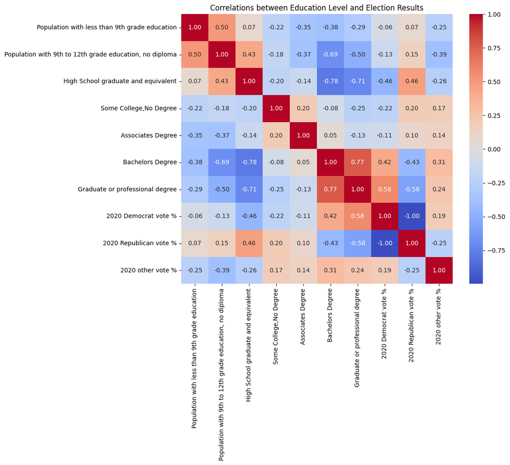

```python
# Wykres korelacji
plt.figure(figsize=(10, 8))
sns.heatmap(cor, annot=True, cmap="coolwarm", fmt=".2f")
plt.title("Correlations between Education Level and Election Results")
plt.show()
```

```python
# Podział na grupy: wysoki odsetek wykształcenia wyższego
degr = dane['Bachelors Degree'].median()
dane['High Education'] = dane['Bachelors Degree'] > degr

# Średnie wyniki wyborcze w grupach
avg_results = dane.groupby('High Education')[['2020 Democrat vote %', '2020 Republican vote %', '2020 other vote %']].mean()
print(avg_results)
```

```
                2020 Democrat vote %  2020 Republican vote %  \
High Education
False                      29.003848               69.449156
True                       37.849668               60.104898

                2020 other vote %
High Education
False                    1.547041
True                     2.043584
```

- Wykształcenie wyższe jest skorelowane z większym poparciem dla Demokratów i mniejszym poparciem dla Republikanów.
- Regiony z wyższym wykształceniem mogą wykazywać większe zainteresowanie kandydatami spoza dwóch głównych partii.

```python
#Średnie dla stanów
avg_data = dane.groupby('state').mean(numeric_only=True).reset_index()

# Tworzenie wykresów interaktywnych
for col in columns_education:
    fig = px.scatter(
        avg_data,
        x=col,
        y=col_results,
        labels={col: f'{col} (%)', 'value': 'Electoral support (%)'},
        title=f'Electoral support vs {col}',
        hover_data=['state'],
    )
    fig.show()
```

[interactive chart not shown]

### 4.2 Zatrudnienie

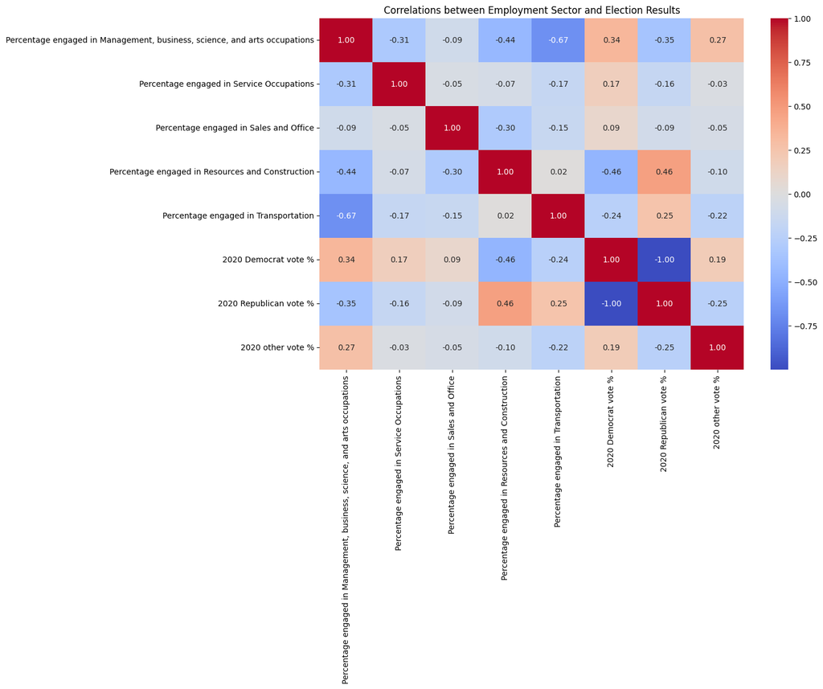

```python
# Kolumny związane z zatrudnieniem
kolumny_zatrudnienie = [
    'Percentage engaged in Management, business, science, and arts occupations',
    'Percentage engaged in Service Occupations',
    'Percentage engaged in Sales and Office',
    'Percentage engaged in Resources and Construction',
    'Percentage engaged in Transportation'
]

# Tworzenie macierzy korelacji dla sektorów zatrudnienia i wyników wyborów
data_korelacja = dane[kolumny_zatrudnienie + col_results]
korelacja_zatrudnienie = data_korelacja.corr()

# Wizualizacja macierzy korelacji
plt.figure(figsize=(12, 8))
sns.heatmap(korelacja_zatrudnienie, annot=True, cmap="coolwarm", fmt=".2f")
plt.title("Correlations between Employment Sector and Election Results")
plt.show()
```

- Regiony z większym odsetkiem zatrudnienia w sektorach wyższych (naukowych, menedżerskich) są bardziej skłonne głosować na Demokratów
- Regiony, gdzie dominują prace w budownictwie i zasobach naturalnych, częściej popierają Republikanów
- Sektory związane z sprzedażą, pracą biurową i usługami, mają słabsze powiązania z wynikami wyborów

```python
for sektor in kolumny_zatrudnienie:
    fig = px.scatter(
        avg_data,
        x=sektor,
        y=col_results,
        labels={
            sektor: f'{sektor} (%)',
            'value': 'Electoral support (%)'
        },
        title=f'Electoral support by Employment Sector: {sektor}',
        hover_data=['state'],
    )
    fig.show()
```

[interactive chart not shown]

### 4.3 Etniczność

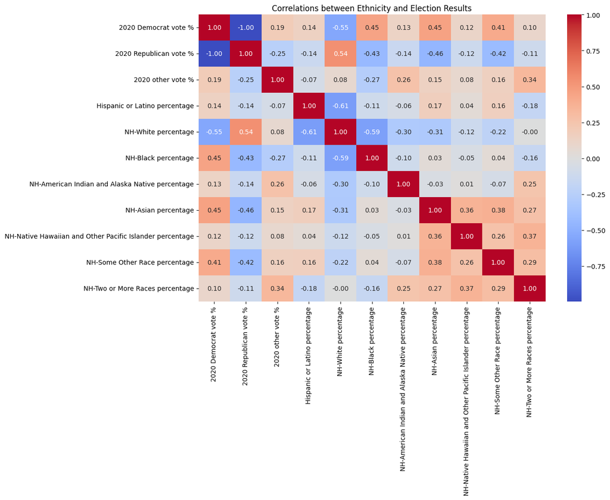

```python
ethnicity_columns = [
    'Hispanic or Latino percentage',
    'NH-White percentage',
    'NH-Black percentage',
    'NH-American Indian and Alaska Native percentage',
    'NH-Asian percentage',
    'NH-Native Hawaiian and Other Pacific Islander percentage',
    'NH-Some Other Race percentage',
    'NH-Two or More Races percentage'
]

# Konwersja wartości procentowych na liczby (jeśli są w formie string z %)
for column in ethnicity_columns:
    if dane[column].dtype == 'object':
        dane[column] = dane[column].str.replace('%', '').astype(float)

# Łączenie danych głosów i etniczności
correlation_data = dane[col_results + ethnicity_columns]

# Obliczanie macierzy korelacji
correlation_matrix = correlation_data.corr()

# Wyświetlenie macierzy korelacji
plt.figure(figsize=(12, 8))
sns.heatmap(correlation_matrix, annot=True, cmap='coolwarm', fmt=".2f")
plt.title("Correlations between Ethnicity and Election Results")
plt.show()
```

- Demokraci mają silne poparcie w regionach z większą różnorodnością etniczną (Afroamerykanie, Azjaci, inne grupy)
- Republikanie największe poparcie mają w regionach o wysokim odsetku białych mieszkańców

```python
# Wykresy interaktywne
for etn in ethnicity_columns:
    fig = px.scatter(
        avg_data,
        x=etn,
        y=col_results,
        labels={
            etn: f'{etn} (%)',
            'value': 'Electoral support (%)'
        },
        title=f'Electoral support by Etjnicity: {etn}',
        hover_data=['state'],
    )
    fig.show()
```

[interactive chart not shown]

# 4.4 Dochód

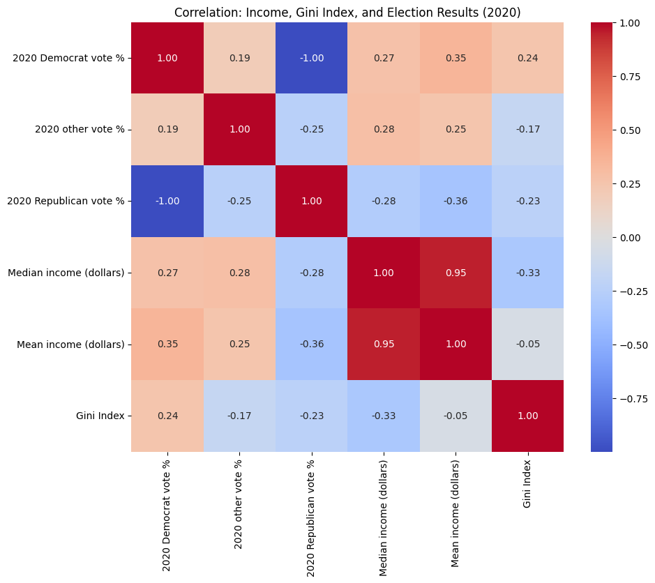

```python
columns_to_convert = ['Median income (dollars)', 'Mean income (dollars)', 'Gini Index']

# Czyszczenie i konwersja danych
for column in columns_to_convert:
    if dane[column].dtype == 'object':
        # Usuwanie przecinków, wyodrębnianie liczb, konwersja na float
        dane[column] = dane[column].str.replace(',', '').str.extract(r'(\d+\.?\d*)')[0]
        dane[column] = dane[column].astype(float)


# Wypełnienie brakujących wartości, jeśli występują
dane[columns_to_convert] = dane[columns_to_convert].fillna(dane[columns_to_convert].mean())

# Dodanie przekonwertowanych kolumn do tabeli 'avg_data'
if 'avg_data' in globals():  # Sprawdzanie, czy 'avg_data' istnieje
    avg_data[columns_to_convert] = dane[columns_to_convert]

# Wybór kolumn do analizy
analysis_columns = [
    '2020 Democrat vote %',
    '2020 other vote %',
    '2020 Republican vote %',
    'Median income (dollars)',
    'Mean income (dollars)',
    'Gini Index'
]
analysis_data = dane[analysis_columns]

# Obliczanie macierzy korelacji
correlation_matrix = analysis_data.corr()

# Wyświetlenie macierzy korelacji
plt.figure(figsize=(10, 8))
sns.heatmap(correlation_matrix, annot=True, cmap='coolwarm', fmt=".2f")
plt.title("Correlation: Income, Gini Index, and Election Results (2020)")
plt.show()
```

```python
# Analiza wpływu medianowego dochodu na wyniki (interaktywny wykres)
fig_income = px.scatter(
    avg_data,
    x='Median income (dollars)',
    y=['2020 Democrat vote %', '2020 Republican vote %'],
    labels={
        'Median income (dollars)': 'Median Income (USD)',
        'value': 'Vote Percentage',
        'variable': 'Party'
    },
    title="Impact of Median Income on Election Results (State-Level Averages)",
    hover_data=['state']
)
fig_income.show()

# Analiza wpływu wskaźnika Giniego na wyniki (interaktywny wykres)
fig_gini = px.scatter(
    avg_data,
    x='Gini Index',
    y=['2020 Democrat vote %', '2020 Republican vote %'],
    labels={
        'Gini Index': 'Gini Index',
        'value': 'Vote Percentage',
        'variable': 'Party'
    },
    title="Impact of the Gini Index on Election Results (State-Level Averages)",
    hover_data=['state']
)
fig_gini.show()
```

[interactive chart not shown]

### 4.4 Klasteryzacja

```python
# Wybór zmiennych
variables = [
    'Hispanic or Latino percentage',
    'NH-White percentage',
    'NH-Black percentage',
    '2020 Democrat vote %',
    '2020 Republican vote %',
    'Percentage engaged in Management, business, science, and arts occupations',
    'Percentage engaged in Service Occupations'
]

# Konwersja procentów na liczby (jeśli to konieczne)
for column in variables:
    if avg_data[column].dtype == 'object':
        avg_data[column] = avg_data[column].str.replace('%', '').astype(float)

# Standaryzacja danych
scaler = StandardScaler()
data_scaled = scaler.fit_transform(avg_data[variables])

# PCA - redukcja wymiarów
pca = PCA(n_components=2)
pca_result = pca.fit_transform(data_scaled)
avg_data['PCA1'] = pca_result[:, 0]
avg_data['PCA2'] = pca_result[:, 1]

# Klasteryzacja K-Means
kmeans = KMeans(n_clusters=5, random_state=42)
avg_data['Cluster'] = kmeans.fit_predict(data_scaled)

# Interaktywna wizualizacja klastrów w przestrzeni PCA
fig = px.scatter(
    avg_data,
    x='PCA1',
    y='PCA2',
    color='Cluster',
    labels={
        "PCA1": "Principal Component 1 (PCA1)",
        "PCA2": "Principal Component 2 (PCA2)",
        "Cluster": "Clusters"
    },
    title="State Clustering Based on PCA",
    hover_data=['state'] + variables
)

fig.show()

# Ładunki PCA
pca_loadings = pd.DataFrame(
    pca.components_.T,
    columns=['PCA1', 'PCA2'],
    index=variables
)

# Wyświetlenie ładunków
print(pca_loadings)
```

[interactive chart not shown]

```
                                                        PCA1      PCA2
Hispanic or Latino percentage                       0.179146  0.515269
NH-White percentage                                -0.394168 -0.415067
NH-Black percentage                                 0.260815 -0.092554
2020 Democrat vote %                                0.537360 -0.078178
2020 Republican vote %                             -0.534353  0.084046
Percentage engaged in Management, business, sci...  0.412259 -0.376394
Percentage engaged in Service Occupations           0.016336  0.631508
```

**Klaster 0 (Nowy Jork, Massachusetts, Vermont, Maryland...)**

- Dominacja zawodów wykwalifikowanych i naukowych
- Silne bastiony Demokratów
- Zróżnicowanie etniczne, ale z przewagą białych nienależących do grupy latynoskiej (NH-White)

**Klaster 1 (Kalifornia, Hawaje, Arizona, Nowy Meksyk...)**

- Regiony zróżnicowane etnicznie
- Zróżnicowane wyniki wyborcze
- Duże miasta są kluczowe

**Klaster 2 (Dystrykt Kolumbii)**

- Skrajne wartości w PCA1 i PCA2
- Ogromne poparcie (93.67%) dla kandydata demokratów

**Klaster 3 (Utah, Montana, Wirginia Zachodnia, Missouri...)**

- Silne poparcie dla Republikanów
- Wysoki odsetek ludności NH-White (białych nienależących do grupy latynoskiej), co jest charakterystyczne dla regionów wiejskich i konserwatywnych
- Różnorodny profil zawodowy

**Klaster 4 (Alabama, Floryda, Georgia, Virginia...)**

- Zróżnicowane wyniki wyborcze
- Wyższy udział zawodów związanych z budownictwem i transportem

**Każdy klaster reprezentuje unikalny profil demograficzny, zawodowy i polityczny, co odzwierciedla zróżnicowanie Stanów Zjednoczonych**  
**Dystrykt Kolumbii jest najbardziej wyjątkowy ze względu na swoje ekstremalne poparcie dla Demokratów.**

## 5. Mapa wyników wyborów według stanów

```python
# Wyciągnięcie danych z 2020 roku
dane_2020 = dane2[dane2.iloc[:, 0] == 2020]
```

```python
# Wybieranie wiersz z maksymalną liczbą głosów (candidatevotes) dla każdego stanu
max_votes_per_state = dane_2020.loc[dane_2020.groupby('state')['candidatevotes'].idxmax()]
#print(max_votes_per_state)
```

```python
# Oczyszczanie nazw stanów (usuwanie zbędnych spacji i konwersja na wielkie litery)
usa['name'] = usa['name'].str.strip().str.upper()
max_votes_per_state['state'] = max_votes_per_state['state'].str.strip().str.upper()

# Złączenie danych
map_data = usa.set_index('name').join(max_votes_per_state.set_index('state'))

# Sprawdzenie wyników
#print(map_data)
```

```python
# Złączenie tabel
map_data = usa.set_index('name').join(max_votes_per_state.set_index('state'))
```

```python
candidate_colors = {
    'BIDEN, JOSEPH R. JR': '#1f77b4',
    'TRUMP, DONALD J.': '#d62728',
    'Other': '#7f7f7f'
}
```

```python
# Dodanie koloru na podstawie zwycięzcy
map_data['color'] = map_data['candidate'].map(candidate_colors)
```

```python
map_data["name"] = [
    "MINNESOTA", "MONTANA", "NORTH DAKOTA", "HAWAII", "IDAHO",
    "WASHINGTON", "ARIZONA", "CALIFORNIA", "COLORADO", "NEVADA",
    "NEW MEXICO", "OREGON", "UTAH", "WYOMING", "ARKANSAS",
    "IOWA", "KANSAS", "MISSOURI", "NEBRASKA", "OKLAHOMA",
    "SOUTH DAKOTA", "LOUISIANA", "TEXAS", "CONNECTICUT", "MASSACHUSETTS",
    "NEW HAMPSHIRE", "RHODE ISLAND", "VERMONT", "ALABAMA", "FLORIDA",
    "GEORGIA", "MISSISSIPPI", "SOUTH CAROLINA", "ILLINOIS", "INDIANA",
    "KENTUCKY", "NORTH CAROLINA", "OHIO", "TENNESSEE", "VIRGINIA",
    "WISCONSIN", "WEST VIRGINIA", "DELAWARE", "DISTRICT OF COLUMBIA",
    "MARYLAND", "NEW JERSEY", "NEW YORK", "PENNSYLVANIA", "MAINE",
    "MICHIGAN", "ALASKA"
]
```

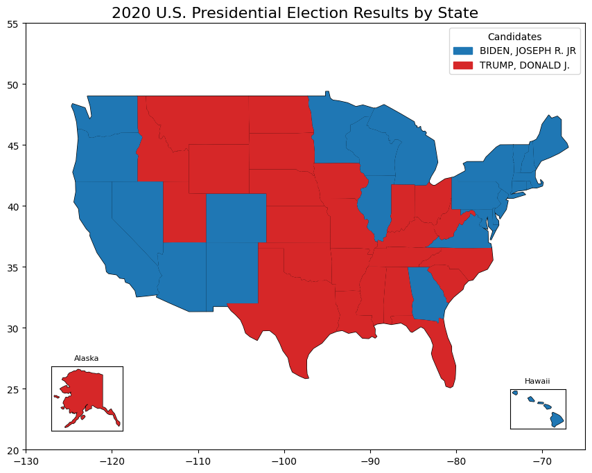

```python
# Główna mapa (kontynentalne USA)
fig, ax = plt.subplots(figsize=(12, 8))
usa.plot(ax=ax, color='lightgrey', edgecolor='black')
map_data.plot(ax=ax, color=map_data['color'])
ax.set_xlim([-130, -65])  # Zakres dla kontynentalnych USA
ax.set_ylim([20, 55])

# Tytuł główny mapy na środku
fig.suptitle('2020 U.S. Presidential Election Results by State', fontsize=16, ha='center', y=0.91)

# Dodanie Alaski w okienku
ax_alaska = inset_axes(ax, width="15%", height="15%", loc='lower left', borderpad=2)
alaska = usa[usa['name'] == 'ALASKA']
alaska_data = map_data[map_data.iloc[:, 3] == 3563]
alaska.plot(ax=ax_alaska, color='lightgrey', edgecolor='black')
alaska_data.plot(ax=ax_alaska, color=alaska_data['color'])
ax_alaska.set_xticks([])
ax_alaska.set_yticks([])
ax_alaska.set_title("Alaska", fontsize=8)

# Dodanie Hawajów w okienku
ax_hawaii = inset_axes(ax, width="10%", height="10%", loc='lower right', borderpad=2)
hawaii = usa[usa['name'] == 'HAWAII']
hawaii_data = map_data[map_data.iloc[:, 3] == 3517]
hawaii.plot(ax=ax_hawaii, color='lightgrey', edgecolor='black')
hawaii_data.plot(ax=ax_hawaii, color=hawaii_data['color'])
ax_hawaii.set_xticks([])
ax_hawaii.set_yticks([])
ax_hawaii.set_title("Hawaii", fontsize=8)

# Wyciągnięcie unikalnych kolorów i odpowiadających im etykiet z danych mapy
unique_colors = map_data[['color', 'candidate']].drop_duplicates()

# Tworzenie elementów legendy na podstawie unikalnych wartości
legend_elements = [
    mpatches.Patch(color=row['color'], label=row['candidate'])
    for _, row in unique_colors.iterrows()
]
ax.legend(handles=legend_elements, title="Candidates", loc='upper right')
plt.show()
```